# Contents

# 3. Random Forest Modeling

**What is Random forest ?**

Random forest is a type of bagging, which avoids the problem of overfitting by randomly selecting multiple subsets and averaging the results of each subset tree model.

```python
from sklearn import preprocessing
from sklearn.ensemble import RandomForestRegressor

model = RandomForestRegressor(max_depth=6, random_state=0, n_estimators=10)
model.fit(X_train, Y_train)
```

```
RandomForestRegressor(max_depth=6, n_estimators=10, random_state=0)
```

# 4. SHAP

SHAP (SHapley Additive exPlanations) is a game-theoretic approach for explaining the effect of each variable in any machine learning model on the outcome in a similar way to regression models. It uses the classical Shapley values from game theory and their associated extensions to relate optimal credit allocation to local explanations.

```python
!pip install shap
```

```
     |████████████████████████████████| 569 kB 8.9 MB/s
```

## 4.1 Variable importance

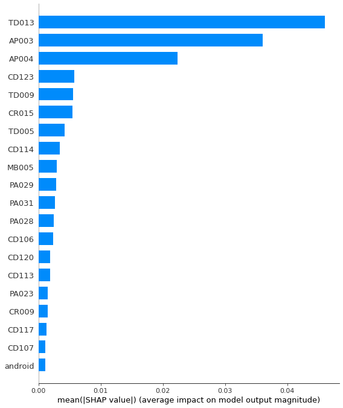

```python
import shap
shap_values = shap.TreeExplainer(model).shap_values(X_train)
shap.summary_plot(shap_values, X_train, plot_type="bar")
```

Among them, TD013 represents the number of times a user has participated in P2P business in the last 6 months, AP003 indicates the user's education level, and AP004 represents the length of time of the loan. However, it is not yet possible to see whether these variables have a positive or negative effect on y.

## 4.2 Summary Plot

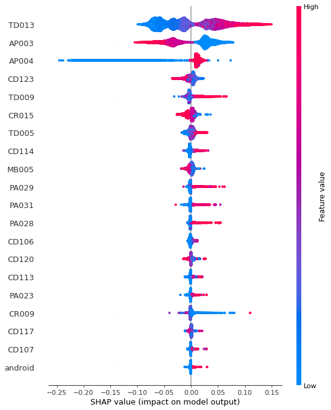

```python
import matplotlib.pyplot as plt
f = plt.figure()
shap.summary_plot(shap_values, X_train)
f.savefig("/summary_plot1.png", bbox_inches='tight', dpi=600)
```

We can see that the top-to-bottom ordering of the variables is the same as the importance graph of the variables. This graph above can give us **more information**, for example, among the first three variables, TD013 and AP004 have a positive effect on the target value, while AP003 has a negative effect. And when the target value higher, the rask of recovering the loan for the bank is also higher.

Combining the meanings of the variables, the results of the random forest model can be explained as follow:

**The customer who less involved in P2P business in the past 6 months, the higher the education level and the shorter the loan cycle the more likely to pay off the loan.**